# TitalGPUReproduction

Samyoga Bhattarai

2026-05-06

## 1. Load Libraries

The paper uses survival analysis methods (Kaplan-Meier + Cox). The paper also does Time Between Failure analysis. So, installing and loading the required libraries.

```r
#installing required packages
#install.packages(c("tidyverse", "lubridate", "Survival", "survminer", "forestmodel"))
#install.packages(c("scales", "patchwork"))

#loading the packages
library(tidyverse)
library(lubridate)
library(survival)
library(survminer)
library(forestmodel)
library(scales)
library(patchwork)
```

## 2. Load the dataset

Two datasets are used: `gc_summary_loc.csv` and `gc_full_csv`.

The csv file (gc_summary_loc.csv) is a pre-processed GPU lifetime data. So, directly using this for the survival analysis technique

```r
# Summary dataset: one row per GPU serial number
data <- read.csv("./data/gc_summary_loc.csv")

str(data)
```

```
## 'data.frame':    30207 obs. of  23 variables:
##  $ SN            : num  3.2e+11 3.2e+11 3.2e+11 3.2e+11 3.2e+11 ...
##  $ time          : int  72916274 72916274 72916274 72916274 72916274 72916274 72916274 72916274 72916274 72916274 ...
##  $ nlife         : int  1 1 1 1 1 1 1 1 1 1 ...
##  $ nloc          : int  1 1 1 1 1 1 1 1 1 1 ...
##  $ last          : chr  "2019-08-01 20:07:33" "2019-08-01 20:07:33" "2019-08-01 20:07:33" "2019-08-01 20:07:33" ...
##  $ col           : int  11 9 6 10 3 13 12 12 14 21 ...
##  $ row           : int  2 3 2 2 2 3 2 5 7 6 ...
##  $ cage          : int  1 1 1 1 1 1 1 2 2 1 ...
##  $ slot          : int  4 2 2 5 2 1 3 1 3 4 ...
##  $ node          : int  1 1 0 1 0 1 1 0 1 1 ...
##  $ max_loc_events: int  0 0 0 0 0 0 0 0 0 0 ...
##  $ time_max_loc  : num  1 1 1 1 1 1 1 1 1 1 ...
##  $ dbe           : int  0 0 0 0 0 0 0 0 0 0 ...
##  $ dbe_loc       : logi  NA NA NA NA NA NA ...
##  $ otb           : int  0 0 0 0 0 0 0 0 0 0 ...
##  $ otb_loc       : logi  NA NA NA NA NA NA ...
##  $ out           : logi  FALSE FALSE FALSE FALSE FALSE FALSE ...
##  $ batch         : chr  "new" "new" "new" "new" ...
##  $ days          : num  844 844 844 844 844 ...
##  $ years         : num  2.31 2.31 2.31 2.31 2.31 ...
##  $ dead          : logi  FALSE FALSE FALSE FALSE FALSE FALSE ...
##  $ dead_otb      : logi  FALSE FALSE FALSE FALSE FALSE FALSE ...
##  $ dead_dbe      : logi  FALSE FALSE FALSE FALSE FALSE FALSE ...
```

```r
summary(data)
```

```
##        SN                 time               nlife            nloc
##  Min.   :3.201e+11   Min.   :     7908   Min.   :1.000   Min.   :1.000
##  1st Qu.:3.237e+11   1st Qu.: 75089376   1st Qu.:1.000   1st Qu.:1.000
##  Median :3.238e+11   Median : 90730468   Median :1.000   Median :1.000
##  Mean   :3.237e+11   Mean   :105328232   Mean   :1.198   Mean   :1.198
##  3rd Qu.:3.238e+11   3rd Qu.:144329609   3rd Qu.:1.000   3rd Qu.:1.000
##  Max.   :3.333e+11   Max.   :179800338   Max.   :6.000   Max.   :6.000
##      last                col             row             cage
##  Length:30207       Min.   : 0.00   Min.   :0.000   Min.   :0.000
##  Class :character   1st Qu.: 6.00   1st Qu.:1.000   1st Qu.:1.000
##  Mode  :character   Median :12.00   Median :3.000   Median :1.000
##                     Mean   :12.25   Mean   :3.359   Mean   :1.191
##                     3rd Qu.:18.00   3rd Qu.:5.000   3rd Qu.:2.000
##                     Max.   :24.00   Max.   :7.000   Max.   :2.000
##       slot            node       max_loc_events      time_max_loc
##  Min.   :0.000   Min.   :0.000   Min.   :  0.0000   Min.   :0.3236
##  1st Qu.:2.000   1st Qu.:0.000   1st Qu.:  0.0000   1st Qu.:1.0000
##  Median :4.000   Median :1.000   Median :  0.0000   Median :1.0000
##  Mean   :3.506   Mean   :1.411   Mean   :  0.2044   Mean   :0.9694
##  3rd Qu.:6.000   3rd Qu.:2.000   3rd Qu.:  0.0000   3rd Qu.:1.0000
##  Max.   :7.000   Max.   :3.000   Max.   :106.0000   Max.   :1.0000
##       dbe            dbe_loc             otb           otb_loc
##  Min.   :  0.0000   Mode :logical   Min.   :0.00000   Mode :logical
##  1st Qu.:  0.0000   FALSE:661       1st Qu.:0.00000   FALSE:202
##  Median :  0.0000   TRUE :3285      Median :0.00000   TRUE :1311
##  Mean   :  0.1598   NA's :26261     Mean   :0.05101   NA's :28694
##  3rd Qu.:  0.0000                   3rd Qu.:0.00000
##  Max.   :106.0000                   Max.   :4.00000
##     out             batch                days               years
##  Mode :logical   Length:30207       Min.   :9.153e-02   Min.   :0.0002508
##  FALSE:18637     Class :character   1st Qu.:8.691e+02   1st Qu.:2.3810685
##  TRUE :11570     Mode  :character   Median :1.050e+03   Median :2.8770443
##                                     Mean   :1.219e+03   Mean   :3.3399363
##                                     3rd Qu.:1.670e+03   3rd Qu.:4.5766619
##                                     Max.   :2.081e+03   Max.   :5.7014313
##     dead          dead_otb        dead_dbe
##  Mode :logical   Mode :logical   Mode :logical
##  FALSE:25118     FALSE:28721     FALSE:26336
##  TRUE :5089      TRUE :1486      TRUE :3871
##
##
##
```

```r
# Full dataset: one row per GPU-location lifetime segment
gc_full <- read.csv("./data/gc_full.csv")
str(gc_full)
```

```
## 'data.frame':    37343 obs. of  7 variables:
##  $ SN      : num  3.2e+11 3.2e+11 3.2e+11 3.2e+11 3.2e+11 ...
##  $ location: chr  "c11-2c1s4n1" "c9-3c1s2n1" "c6-2c1s2n0" "c10-2c1s5n1" ...
##  $ insert  : chr  "2017-04-09 21:36:19" "2017-04-09 21:36:19" "2017-04-09 21:36:19" "2017-04-09 21:36:19" ...
##  $ remove  : chr  "2019-08-01 20:07:33" "2019-08-01 20:07:33" "2019-08-01 20:07:33" "2019-08-01 20:07:33" ...
##  $ duration: int  72916274 72916274 72916274 72916274 72916274 72916274 72916274 72916274 72916274 72916274 ...
##  $ out     : logi  FALSE FALSE FALSE FALSE FALSE FALSE ...
##  $ event   : chr  "" "" "" "" ...
```

## 3. Survival Analysis Setup

### 3.1 Cleaning and pre-processing dataset

Defining the required variables for survival analysis: Here, the two columns ‘years’ and ‘dead’ from the dataset are crucial variables as years shows the lifetime of each GPU and dead is the event where 1 shows GPU failure and 0 shows GPU did not fail so censored. The event can be Dual Bit Error (DBE) or Off The Bus (OTB).

```r
#survival time and event variables
data$time <- data$years
data$event <- data$dead
```

```r
#cleaning the data to avoid missing values
data <- data %>% filter(!is.na(time), time > 0)
```

Converting Predictors to categorical variables using factor for cox model:

```r
data$col <- as.factor(data$col)
data$row  <- as.factor(data$row)
data$cage <- as.factor(data$cage)
data$slot <- as.factor(data$slot)
data$node <- as.factor(data$node)

#adding batch variable and converting to categorical for considering old and new batch. Old batch - inserted before 2016 and new batch - inserted in 2016 or later.
data$batch <- as.factor(data$batch)

cat("Total GPUs in analysis:", nrow(data), "\n")
```

```
## Total GPUs in analysis: 30207
```

```r
cat("Events (failures):", sum(data$event), "\n")
```

```
## Events (failures): 5089
```

```r
cat("Censored:", sum(data$event == 0), "\n")
```

```
## Censored: 25118
```

```r
cat("\nBatch breakdown:\n")
```

```
##
## Batch breakdown:
```

```r
print(table(data$batch))
```

```
##
##   new   old
## 11370 18837
```

```r
cat("\nFailures by batch:\n")
```

```
##
## Failures by batch:
```

```r
print(table(data$batch, data$event))
```

```
##
##       FALSE  TRUE
##   new 11308    62
##   old 13810  5027
```

### 3.2 Creating Objects for Survival Analysis

```r
#double bit error object for survival analysis
surv_dbe_obj <- Surv(time = data$time, event = data$dead_dbe)
#OTB error object for survival analysis
surv_otb_obj <- Surv(time = data$time, event = data$dead_otb)
#combined DBE and OTB for survival analysis
surv_obj <- Surv(time = data$time, event = data$event)
```

## 4. Survival Analysis Method 1: Kaplan-Meier Estimation

### 4.1 Kaplan Meier Fit by Cage

```
## Ignoring unknown labels:
## • colour : "Strata"
```

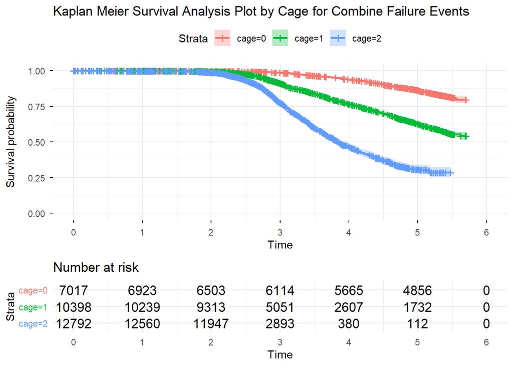

```r
kaplanmeier_fit <- survfit(surv_obj ~ cage, data = data)

plot_kaplanmeier <- ggsurvplot(
  kaplanmeier_fit,
  data = data,
  conf.int = TRUE,
  risk.table = TRUE,
  ggtheme = theme_minimal(),
  risk.table.height = 0.30,
  title = "Kaplan Meier Survival Analysis Plot by Cage for Combine Failure Events"
)

print(plot_kaplanmeier)
```

### 4.2 Kaplan-Meier Analysis for DBE and OTB Event by Cage

```
## Ignoring unknown labels:
## • colour : "Strata"
```

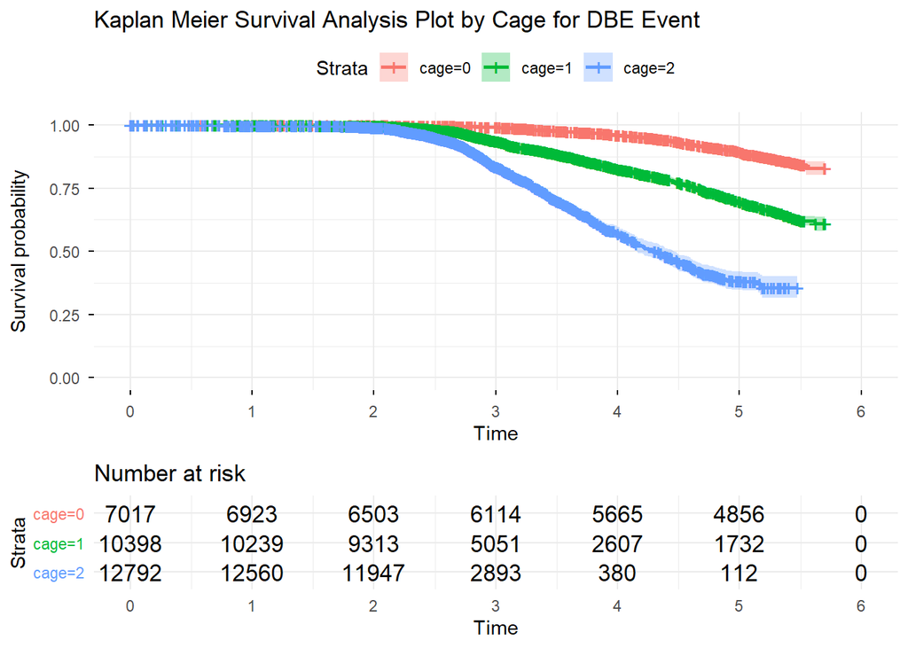

```r
kaplanmeier_fit_dbe <- survfit(surv_dbe_obj ~ cage, data = data)

plot_kaplanmeier_DBE <- ggsurvplot(
  kaplanmeier_fit_dbe,
  data = data,
  conf.int = TRUE,
  risk.table = TRUE,
  ggtheme = theme_minimal(),
  risk.table.height = 0.30,
  title = "Kaplan Meier Survival Analysis Plot by Cage for DBE Event"
)

print(plot_kaplanmeier_DBE)
```

```
## Ignoring unknown labels:
## • colour : "Strata"
```

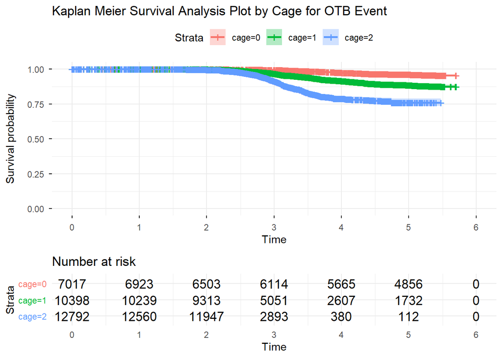

```r
kaplanmeier_fit_otb <- survfit(surv_otb_obj ~ cage, data = data)

plot_kaplanmeier_OTB <- ggsurvplot(
  kaplanmeier_fit_otb,
  data = data,
  conf.int = TRUE,
  risk.table = TRUE,
  ggtheme = theme_minimal(),
  risk.table.height = 0.30,
  title = "Kaplan Meier Survival Analysis Plot by Cage for OTB Event"
)

print(plot_kaplanmeier_OTB)
```

### 4.3 Kaplan-Meier Analysis for Old vs New Batch Data

```
## Ignoring unknown labels:
## • colour : "Strata"
```

[figure not shown]

```r
kaplanmeier_fit_batch <- survfit(surv_obj ~ batch, data = data)

plot_kaplanmeier <- ggsurvplot(
  kaplanmeier_fit_batch,
  data = data,
  conf.int = TRUE,
  risk.table = TRUE,
  ggtheme = theme_minimal(),
  risk.table.height = 0.30,
  legend.labs = c("Old Batch", "New Batch"),
  title = "Kaplan Meier Survival Analysis Plot by Batch for Old vs New"
)

print(plot_kaplanmeier)
```

### 4.4 Kaplan-Meier log-log diagnostic model plot

For proportional hazards check:

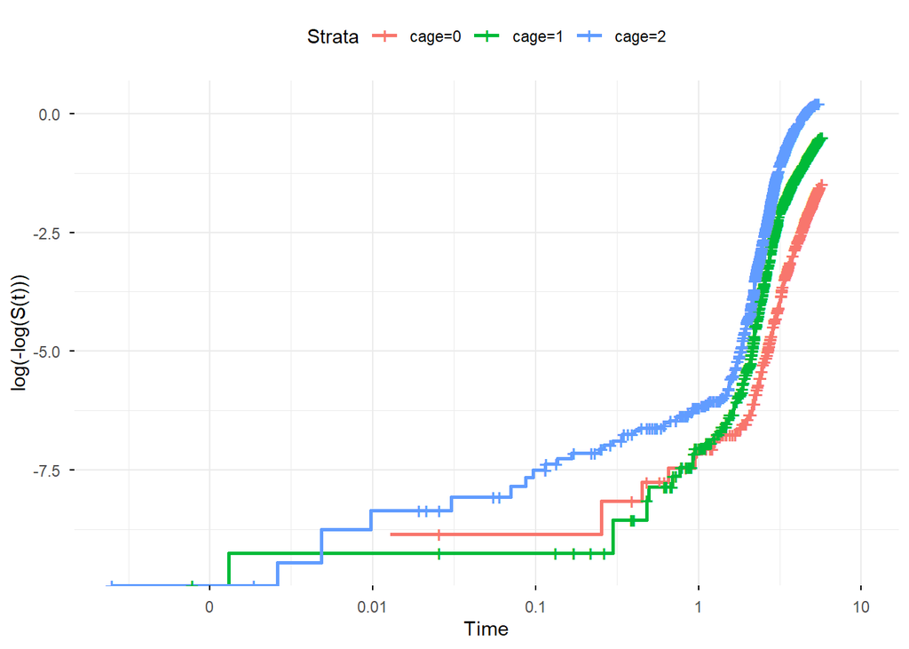

```r
ggsurvplot(
  kaplanmeier_fit,
  data = data,
  fun = "cloglog",
  ggtheme = theme_minimal()
)
```

## 5. Survival Analysis Method 2: Cox proportional hazard model

### 5.1 Cox model with All Location Covariates

```r
cox_model <- coxph(Surv(time, event) ~ col + row + cage + slot + node + batch, data = data
)

summary(cox_model)
```

```
## Call:
## coxph(formula = Surv(time, event) ~ col + row + cage + slot +
##     node + batch, data = data)
##
##   n= 30207, number of events= 5089
##
##               coef exp(coef)  se(coef)       z Pr(>|z|)
## col1      0.116561  1.123626  0.108300   1.076 0.281804
## col2     -0.506745  0.602453  0.126678  -4.000 6.33e-05 ***
## col3      0.443265  1.557785  0.102025   4.345 1.39e-05 ***
## col4     -0.577496  0.561302  0.130684  -4.419 9.91e-06 ***
## col5      0.737485  2.090672  0.097915   7.532 5.00e-14 ***
## col6     -0.214932  0.806596  0.117710  -1.826 0.067857 .
## col7      0.925616  2.523421  0.101870   9.086  < 2e-16 ***
## col8      0.168453  1.183472  0.116061   1.451 0.146664
## col9      1.062407  2.893328  0.099172  10.713  < 2e-16 ***
## col10     0.574262  1.775819  0.106988   5.368 7.98e-08 ***
## col11     0.934854  2.546842  0.100818   9.273  < 2e-16 ***
## col12     0.889477  2.433857  0.101580   8.756  < 2e-16 ***
## col13     0.921859  2.513959  0.100209   9.199  < 2e-16 ***
## col14     0.914860  2.496426  0.101280   9.033  < 2e-16 ***
## col15     1.039065  2.826572  0.099304  10.463  < 2e-16 ***
## col16     0.888122  2.430561  0.101649   8.737  < 2e-16 ***
## col17     1.124719  3.079351  0.103759  10.840  < 2e-16 ***
## col18     1.078379  2.939910  0.105234  10.247  < 2e-16 ***
## col19     1.061966  2.892050  0.105526  10.064  < 2e-16 ***
## col20     1.269074  3.557557  0.103261  12.290  < 2e-16 ***
## col21     1.303561  3.682388  0.103130  12.640  < 2e-16 ***
## col22     1.421790  4.144531  0.100592  14.134  < 2e-16 ***
## col23     1.296790  3.657538  0.102968  12.594  < 2e-16 ***
## col24     1.129228  3.093266  0.105597  10.694  < 2e-16 ***
## row1     -0.263713  0.768194  0.053030  -4.973 6.60e-07 ***
## row2     -0.498470  0.607459  0.054868  -9.085  < 2e-16 ***
## row3     -0.783347  0.456874  0.054295 -14.428  < 2e-16 ***
## row4     -0.738304  0.477924  0.052342 -14.105  < 2e-16 ***
## row5     -0.950889  0.386398  0.055050 -17.273  < 2e-16 ***
## row6     -1.151335  0.316214  0.058466 -19.693  < 2e-16 ***
## row7     -1.244089  0.288203  0.054203 -22.952  < 2e-16 ***
## cage1     1.798642  6.041436  0.043137  41.696  < 2e-16 ***
## cage2     3.089746 21.971492  0.047789  64.654  < 2e-16 ***
```

[output cut: 49 more lines]

```
## slot2       0.8545    1.17033    0.7638    0.9558
## slot3       0.8167    1.22440    0.7292    0.9147
## slot4       0.9376    1.06652    0.8394    1.0474
## slot5       1.0051    0.99489    0.9011    1.1211
## slot6       1.1894    0.84073    1.0688    1.3237
## slot7       1.2137    0.82393    1.0923    1.3485
## node1       1.0837    0.92277    1.0077    1.1654
## node2       0.3542    2.82306    0.3261    0.3848
## node3       0.2632    3.79922    0.2410    0.2874
## batchold   17.7546    0.05632   13.7689   22.8940
##
## Concordance= 0.823  (se = 0.003 )
## Likelihood ratio test= 6801  on 44 df,   p=<2e-16
## Wald test            = 5819  on 44 df,   p=<2e-16
## Score (logrank) test = 6629  on 44 df,   p=<2e-16
```

### 5.2 Interpreting Hazard Ratios

```r
hazard_ratio <- exp(coef(cox_model))
hazard_ratio
```

```
##       col1       col2       col3       col4       col5       col6       col7
##  1.1236259  0.6024533  1.5577851  0.5613021  2.0906715  0.8065959  2.5234212
##       col8       col9      col10      col11      col12      col13      col14
##  1.1834721  2.8933278  1.7758186  2.5468424  2.4338572  2.5139591  2.4964263
##      col15      col16      col17      col18      col19      col20      col21
##  2.8265719  2.4305607  3.0793512  2.9399096  2.8920501  3.5575568  3.6823877
##      col22      col23      col24       row1       row2       row3       row4
##  4.1445309  3.6575377  3.0932662  0.7681942  0.6074593  0.4568743  0.4779237
##       row5       row6       row7      cage1      cage2      slot1      slot2
##  0.3863975  0.3162143  0.2882034  6.0414362 21.9714919  0.9002163  0.8544595
##      slot3      slot4      slot5      slot6      slot7      node1      node2
##  0.8167292  0.9376318  1.0051401  1.1894413  1.2136885  1.0836976  0.3542253
##      node3   batchold
##  0.2632122 17.7545686
```

### 5.3 Forest Plot

```r
forest_model(cox_model)
```

```
## `height` was translated to `width`.
```

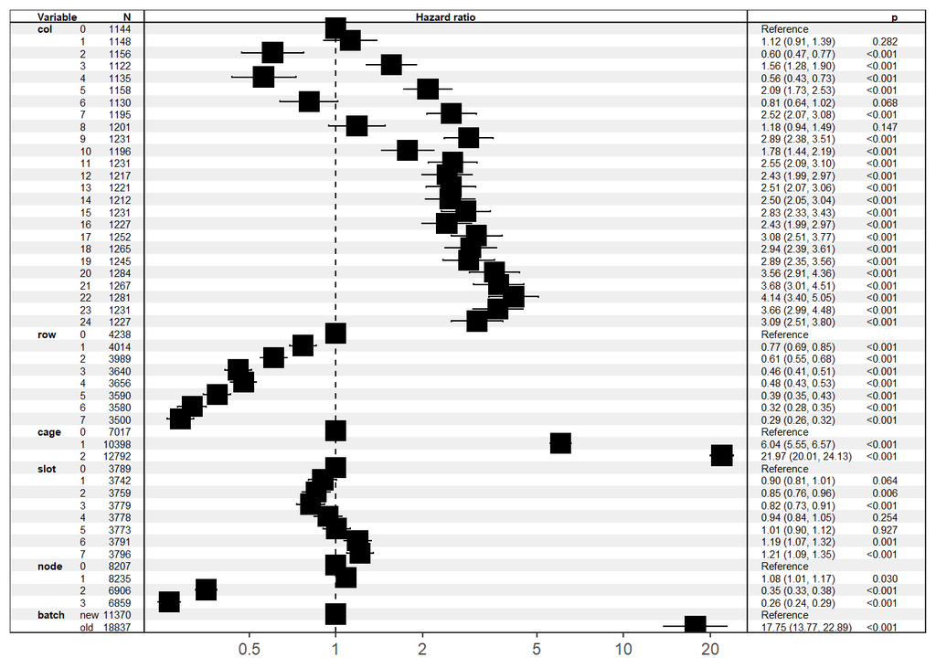

### 5.4. Schoenfeld residual test

```r
ph_test <- cox.zph(cox_model)
ph_test
```

```
##        chisq df       p
## col    104.4 24 5.3e-12
## row     86.8  7 5.6e-16
## cage    34.9  2 2.7e-08
## slot    27.8  7 0.00024
## node    60.6  3 4.4e-13
## batch   23.1  1 1.6e-06
## GLOBAL 375.0 44 < 2e-16
```

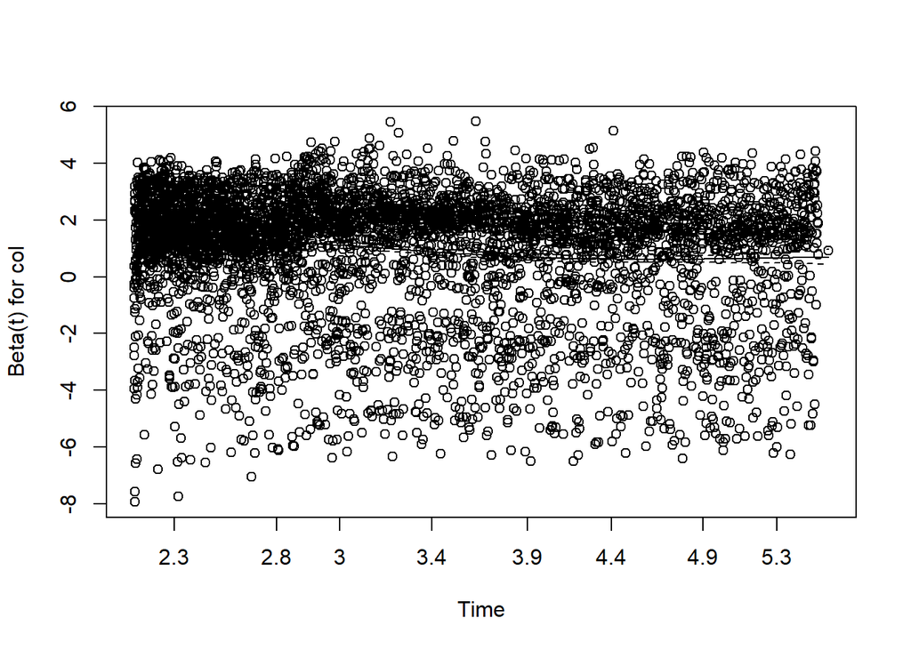

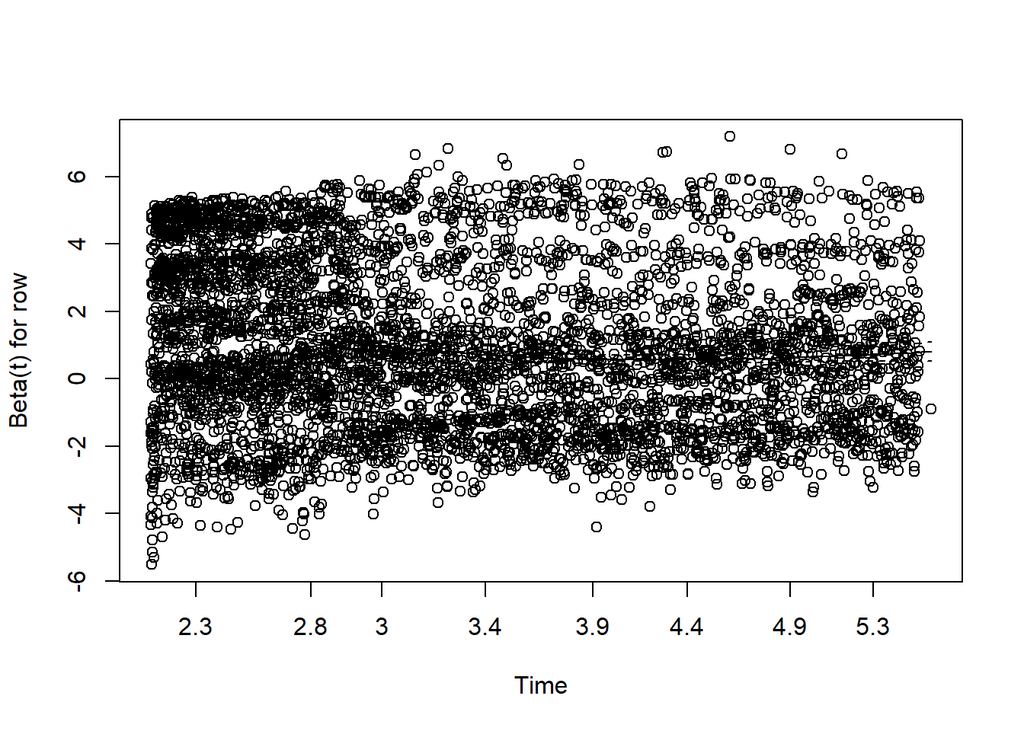

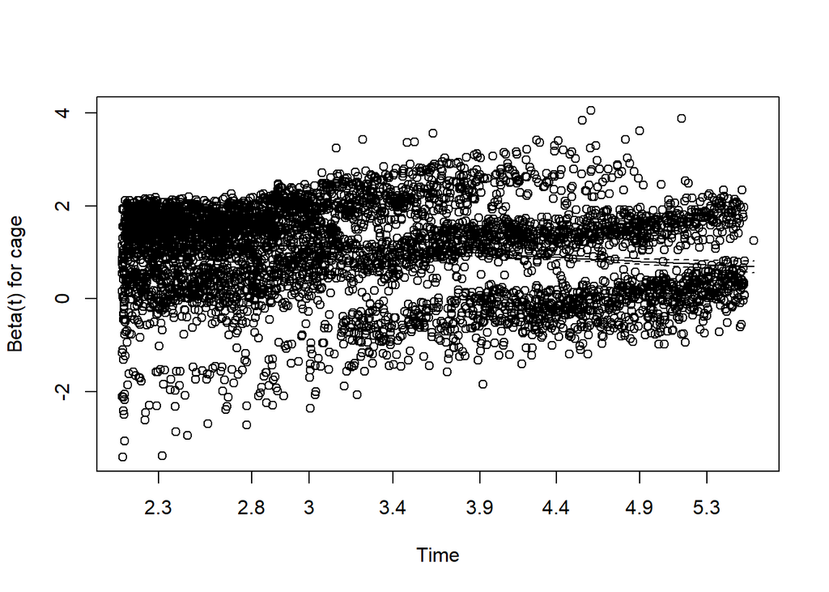

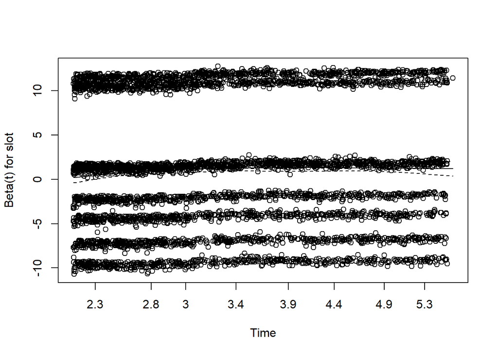

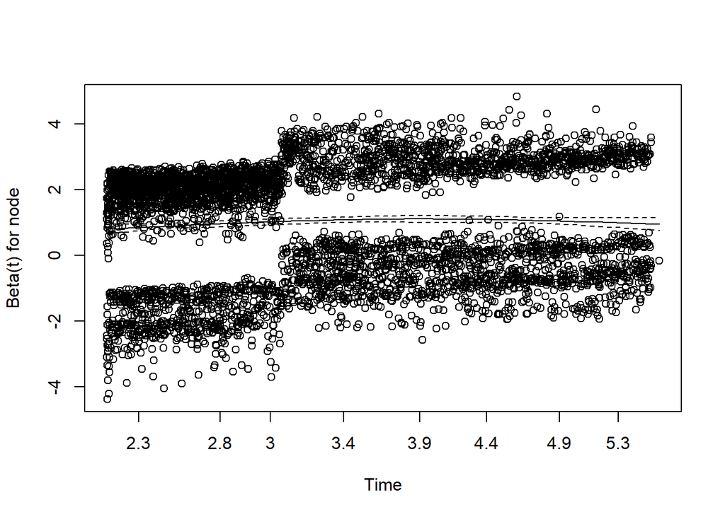

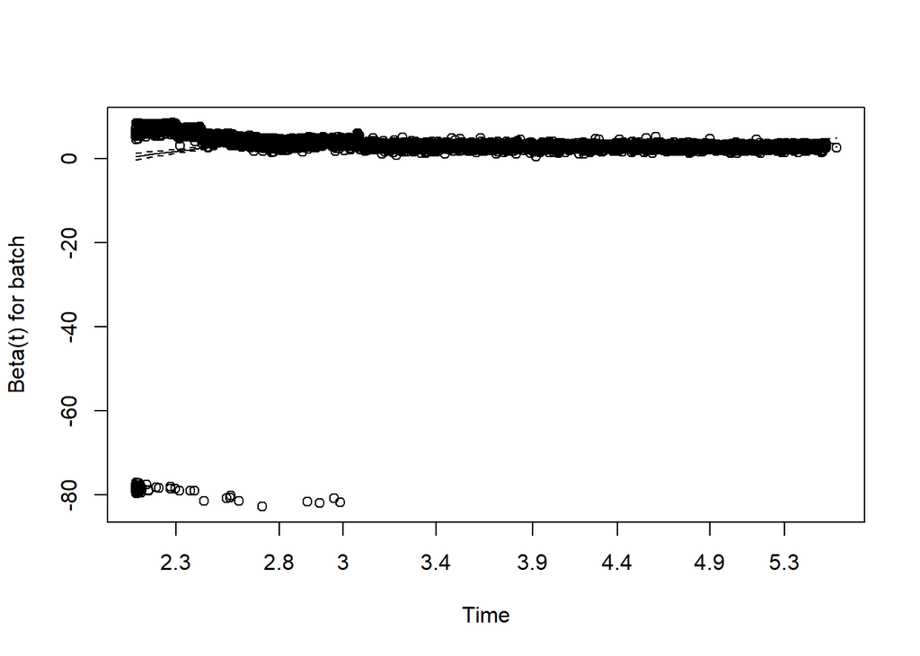

```r
plot(ph_test)
```

```r
summary(cox_model)
```

```
## Call:
## coxph(formula = Surv(time, event) ~ col + row + cage + slot +
##     node + batch, data = data)
##
##   n= 30207, number of events= 5089
##
##               coef exp(coef)  se(coef)       z Pr(>|z|)
## col1      0.116561  1.123626  0.108300   1.076 0.281804
## col2     -0.506745  0.602453  0.126678  -4.000 6.33e-05 ***
## col3      0.443265  1.557785  0.102025   4.345 1.39e-05 ***
## col4     -0.577496  0.561302  0.130684  -4.419 9.91e-06 ***
## col5      0.737485  2.090672  0.097915   7.532 5.00e-14 ***
## col6     -0.214932  0.806596  0.117710  -1.826 0.067857 .
## col7      0.925616  2.523421  0.101870   9.086  < 2e-16 ***
## col8      0.168453  1.183472  0.116061   1.451 0.146664
## col9      1.062407  2.893328  0.099172  10.713  < 2e-16 ***
## col10     0.574262  1.775819  0.106988   5.368 7.98e-08 ***
## col11     0.934854  2.546842  0.100818   9.273  < 2e-16 ***
## col12     0.889477  2.433857  0.101580   8.756  < 2e-16 ***
## col13     0.921859  2.513959  0.100209   9.199  < 2e-16 ***
## col14     0.914860  2.496426  0.101280   9.033  < 2e-16 ***
## col15     1.039065  2.826572  0.099304  10.463  < 2e-16 ***
## col16     0.888122  2.430561  0.101649   8.737  < 2e-16 ***
## col17     1.124719  3.079351  0.103759  10.840  < 2e-16 ***
## col18     1.078379  2.939910  0.105234  10.247  < 2e-16 ***
## col19     1.061966  2.892050  0.105526  10.064  < 2e-16 ***
## col20     1.269074  3.557557  0.103261  12.290  < 2e-16 ***
## col21     1.303561  3.682388  0.103130  12.640  < 2e-16 ***
## col22     1.421790  4.144531  0.100592  14.134  < 2e-16 ***
## col23     1.296790  3.657538  0.102968  12.594  < 2e-16 ***
## col24     1.129228  3.093266  0.105597  10.694  < 2e-16 ***
## row1     -0.263713  0.768194  0.053030  -4.973 6.60e-07 ***
## row2     -0.498470  0.607459  0.054868  -9.085  < 2e-16 ***
## row3     -0.783347  0.456874  0.054295 -14.428  < 2e-16 ***
## row4     -0.738304  0.477924  0.052342 -14.105  < 2e-16 ***
## row5     -0.950889  0.386398  0.055050 -17.273  < 2e-16 ***
## row6     -1.151335  0.316214  0.058466 -19.693  < 2e-16 ***
## row7     -1.244089  0.288203  0.054203 -22.952  < 2e-16 ***
## cage1     1.798642  6.041436  0.043137  41.696  < 2e-16 ***
## cage2     3.089746 21.971492  0.047789  64.654  < 2e-16 ***
```

[output cut: 49 more lines]

```
## slot2       0.8545    1.17033    0.7638    0.9558
## slot3       0.8167    1.22440    0.7292    0.9147
## slot4       0.9376    1.06652    0.8394    1.0474
## slot5       1.0051    0.99489    0.9011    1.1211
## slot6       1.1894    0.84073    1.0688    1.3237
## slot7       1.2137    0.82393    1.0923    1.3485
## node1       1.0837    0.92277    1.0077    1.1654
## node2       0.3542    2.82306    0.3261    0.3848
## node3       0.2632    3.79922    0.2410    0.2874
## batchold   17.7546    0.05632   13.7689   22.8940
##
## Concordance= 0.823  (se = 0.003 )
## Likelihood ratio test= 6801  on 44 df,   p=<2e-16
## Wald test            = 5819  on 44 df,   p=<2e-16
## Score (logrank) test = 6629  on 44 df,   p=<2e-16
```

### 5.5. Adjusted survival curves by cage

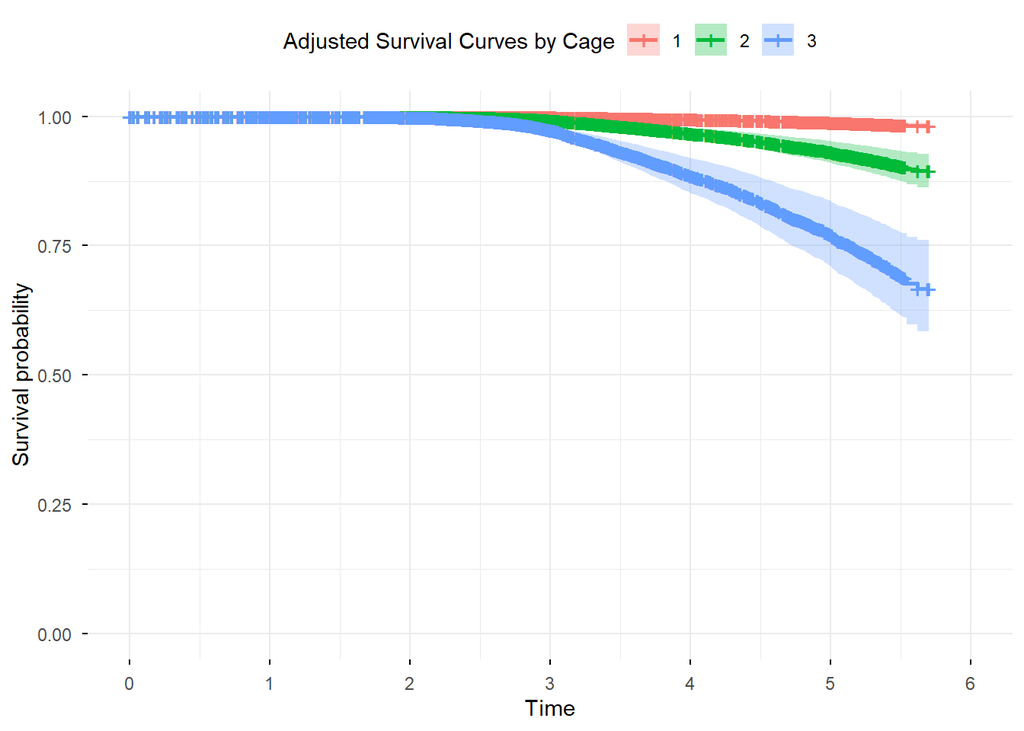

```r
newdata_adj <- expand.grid(
  cage = levels(data$cage),
  col  = levels(data$col)[1],
  row  = levels(data$row)[1],
  slot = levels(data$slot)[1],
  node = levels(data$node)[1],
  batch = levels(data$batch)[1]
)

fit_adj <- survfit(cox_model, newdata = newdata_adj)

ggsurvplot(
  fit_adj,
  data = newdata_adj,
  conf.int = TRUE,
  ggtheme = theme_minimal(),
  legend.title = "Adjusted Survival Curves by Cage"
)
```

### 5.6. Separate Cox model for DBE and OTB error events

```r
cox_dbe <- coxph( Surv(time, dead_dbe) ~ col + row + cage + slot + node + batch, data = data)
cox_otb <- coxph( Surv(time, dead_otb) ~ col + row + cage + slot + node + batch, data = data)

cat("Cox Model: DBE Event\n\n")
```

```
## Cox Model: DBE Event
```

```r
summary(cox_dbe)
```

```
## Call:
## coxph(formula = Surv(time, dead_dbe) ~ col + row + cage + slot +
##     node + batch, data = data)
##
##   n= 30207, number of events= 3871
##
##              coef exp(coef) se(coef)       z Pr(>|z|)
## col1      0.16082   1.17448  0.12496   1.287 0.198086
## col2     -0.38274   0.68199  0.14203  -2.695 0.007041 **
## col3      0.51556   1.67458  0.11743   4.390 1.13e-05 ***
## col4     -0.54250   0.58129  0.15061  -3.602 0.000316 ***
## col5      0.73861   2.09303  0.11444   6.454 1.09e-10 ***
## col6     -0.07269   0.92989  0.13168  -0.552 0.580939
## col7      0.95566   2.60039  0.11816   8.088 6.08e-16 ***
## col8      0.28621   1.33138  0.13088   2.187 0.028754 *
## col9      1.05812   2.88095  0.11606   9.117  < 2e-16 ***
## col10     0.65618   1.92742  0.12236   5.363 8.19e-08 ***
## col11     0.94778   2.57998  0.11741   8.073 6.88e-16 ***
## col12     0.94471   2.57208  0.11719   8.061 7.55e-16 ***
## col13     0.97105   2.64071  0.11587   8.381  < 2e-16 ***
## col14     0.95513   2.59900  0.11729   8.143 3.85e-16 ***
## col15     1.02116   2.77642  0.11641   8.772  < 2e-16 ***
## col16     0.90065   2.46121  0.11841   7.606 2.83e-14 ***
## col17     1.10538   3.02038  0.12162   9.089  < 2e-16 ***
## col18     1.06728   2.90745  0.12330   8.656  < 2e-16 ***
## col19     1.05078   2.85988  0.12364   8.499  < 2e-16 ***
## col20     1.30877   3.70160  0.11979  10.926  < 2e-16 ***
## col21     1.37570   3.95784  0.11876  11.583  < 2e-16 ***
## col22     1.52053   4.57466  0.11543  13.173  < 2e-16 ***
## col23     1.33437   3.79761  0.11945  11.171  < 2e-16 ***
## col24     1.15997   3.18983  0.12259   9.462  < 2e-16 ***
## row1     -0.24317   0.78414  0.06107  -3.982 6.83e-05 ***
## row2     -0.47020   0.62488  0.06307  -7.456 8.93e-14 ***
## row3     -0.77728   0.45965  0.06230 -12.477  < 2e-16 ***
## row4     -0.76860   0.46366  0.06073 -12.655  < 2e-16 ***
## row5     -0.94804   0.38750  0.06332 -14.973  < 2e-16 ***
## row6     -1.15078   0.31639  0.06722 -17.119  < 2e-16 ***
## row7     -1.24095   0.28911  0.06236 -19.899  < 2e-16 ***
## cage1     1.82270   6.18854  0.04899  37.204  < 2e-16 ***
## cage2     3.13632  23.01895  0.05505  56.972  < 2e-16 ***
```

[output cut: 49 more lines]

```
## slot2       0.7988    1.25195    0.7030    0.9076
## slot3       0.7625    1.31155    0.6701    0.8676
## slot4       0.9158    1.09189    0.8084    1.0375
## slot5       0.9284    1.07717    0.8195    1.0517
## slot6       1.1381    0.87869    1.0083    1.2846
## slot7       1.1720    0.85323    1.0404    1.3203
## node1       1.0863    0.92054    0.9988    1.1815
## node2       0.3495    2.86091    0.3178    0.3845
## node3       0.2581    3.87498    0.2332    0.2856
## batchold   15.3769    0.06503   11.6387   20.3157
##
## Concordance= 0.822  (se = 0.003 )
## Likelihood ratio test= 5118  on 44 df,   p=<2e-16
## Wald test            = 4435  on 44 df,   p=<2e-16
## Score (logrank) test = 5010  on 44 df,   p=<2e-16
```

```r
cat("Cox Model: OTB Event\n\n")
```

```
## Cox Model: OTB Event
```

```r
summary(cox_otb)
```

```
## Call:
## coxph(formula = Surv(time, dead_otb) ~ col + row + cage + slot +
##     node + batch, data = data)
##
##   n= 30207, number of events= 1486
##
##              coef exp(coef) se(coef)       z Pr(>|z|)
## col1      0.10900   1.11517  0.19642   0.555 0.578917
## col2     -0.88986   0.41071  0.26261  -3.389 0.000703 ***
## col3      0.21310   1.23751  0.19361   1.101 0.271033
## col4     -0.64797   0.52311  0.24280  -2.669 0.007614 **
## col5      0.82966   2.29253  0.17318   4.791 1.66e-06 ***
## col6     -0.73233   0.48079  0.25387  -2.885 0.003919 **
## col7      0.83395   2.30239  0.18780   4.441 8.97e-06 ***
## col8     -0.21091   0.80985  0.23741  -0.888 0.374336
## col9      1.03851   2.82500  0.17905   5.800 6.63e-09 ***
## col10     0.40397   1.49777  0.20265   1.994 0.046206 *
## col11     0.98002   2.66452  0.18036   5.434 5.52e-08 ***
## col12     0.73863   2.09306  0.18988   3.890 0.000100 ***
## col13     0.86750   2.38096  0.18285   4.744 2.09e-06 ***
## col14     0.80805   2.24352  0.18709   4.319 1.57e-05 ***
## col15     1.11259   3.04221  0.17652   6.303 2.92e-10 ***
## col16     0.86711   2.38003  0.18404   4.712 2.46e-06 ***
## col17     1.24004   3.45575  0.18258   6.792 1.11e-11 ***
## col18     1.11896   3.06166  0.18707   5.982 2.21e-09 ***
## col19     1.13801   3.12054  0.18619   6.112 9.84e-10 ***
## col20     1.28316   3.60804  0.18444   6.957 3.47e-12 ***
## col21     1.21822   3.38115  0.18860   6.459 1.05e-10 ***
## col22     1.27716   3.58644  0.18584   6.872 6.31e-12 ***
## col23     1.29805   3.66214  0.18469   7.028 2.09e-12 ***
## col24     0.98814   2.68624  0.19582   5.046 4.51e-07 ***
## row1     -0.35272   0.70277  0.09523  -3.704 0.000212 ***
## row2     -0.58732   0.55582  0.09863  -5.955 2.60e-09 ***
## row3     -0.85785   0.42407  0.09998  -8.580  < 2e-16 ***
## row4     -0.70528   0.49397  0.09296  -7.587 3.28e-14 ***
## row5     -1.03959   0.35360  0.10140 -10.252  < 2e-16 ***
## row6     -1.23404   0.29111  0.10799 -11.427  < 2e-16 ***
## row7     -1.31412   0.26871  0.09932 -13.231  < 2e-16 ***
## cage1     1.73761   5.68376  0.08424  20.628  < 2e-16 ***
## cage2     3.00580  20.20240  0.08848  33.971  < 2e-16 ***
```

[output cut: 49 more lines]

```
## slot2       0.9818    1.01857    0.7940    1.2139
## slot3       1.0271    0.97362    0.8329    1.2666
## slot4       0.9879    1.01230    0.7977    1.2234
## slot5       1.1961    0.83603    0.9742    1.4686
## slot6       1.3503    0.74058    1.1021    1.6544
## slot7       1.2612    0.79292    1.0293    1.5453
## node1       1.0707    0.93399    0.9393    1.2204
## node2       0.3778    2.64719    0.3249    0.4392
## node3       0.2702    3.70096    0.2296    0.3180
## batchold   37.2300    0.02686   20.4899   67.6466
##
## Concordance= 0.834  (se = 0.005 )
## Likelihood ratio test= 2221  on 44 df,   p=<2e-16
## Wald test            = 1800  on 44 df,   p=<2e-16
## Score (logrank) test = 2139  on 44 df,   p=<2e-16
```

```
## `height` was translated to `width`.
```

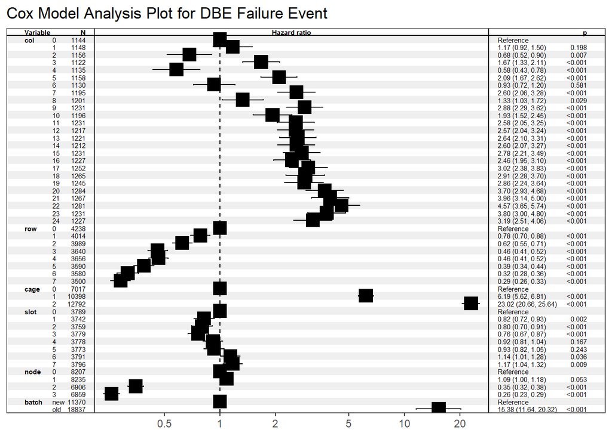

```r
forest_model_dbe <- forest_model(cox_dbe) + ggtitle("Cox Model Analysis Plot for DBE Failure Event")
forest_model_otb <- forest_model(cox_otb) + ggtitle("Cox Model Analysis Plot for OTB Failure Event")

print(forest_model_dbe)
```

```r
print(forest_model_otb)
```

```
## `height` was translated to `width`.
```

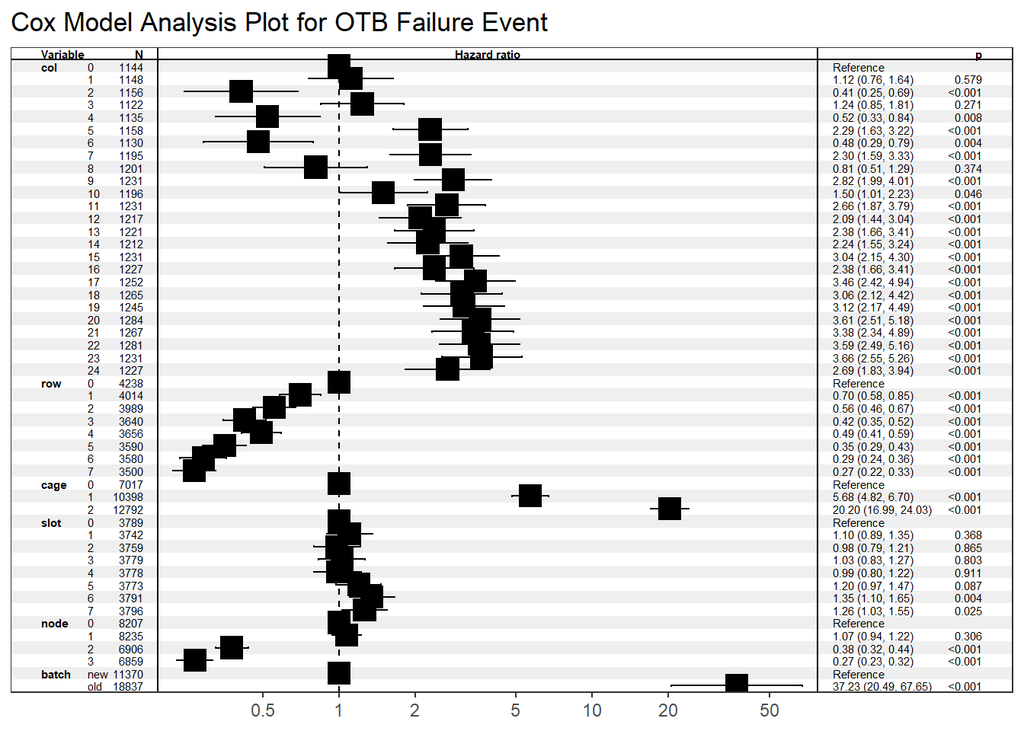

### 5.7 Cox model Analysis for Old and New Batch

```r
levels(data$batch)
```

```
## [1] "new" "old"
```

```r
data_old <- data %>% filter(batch == "old")
data_new <- data %>% filter(batch == "new")
```

```r
cox_old  <- coxph(Surv(time, event) ~ col + row + cage + slot + node, data = data_old)

#grouping column into fewer bins to avoid plot error;
data_new$col_group <- cut(as.numeric(as.character(data_new$col)),breaks = c(0, 8, 16, 24), labels = c("low", "mid", "high"))

cox_new <- coxph(Surv(time, event) ~ col_group + row + cage + slot + node, data = data_new)

cat("Cox Model: Old Batch\n\n")
```

```
## Cox Model: Old Batch
```

```r
summary(cox_old)
```

```
## Call:
## coxph(formula = Surv(time, event) ~ col + row + cage + slot +
##     node, data = data_old)
##
##   n= 18837, number of events= 5027
##
##           coef exp(coef) se(coef)       z Pr(>|z|)
## col1   0.11922   1.12661  0.10862   1.098 0.272408
## col2  -0.50934   0.60089  0.12723  -4.003 6.25e-05 ***
## col3   0.44296   1.55731  0.10240   4.326 1.52e-05 ***
## col4  -0.58067   0.55952  0.13131  -4.422 9.76e-06 ***
## col5   0.74124   2.09854  0.09824   7.545 4.51e-14 ***
## col6  -0.20574   0.81404  0.11786  -1.746 0.080876 .
## col7   0.93820   2.55539  0.10225   9.175  < 2e-16 ***
## col8   0.16883   1.18392  0.11672   1.446 0.148047
## col9   1.08407   2.95669  0.09937  10.910  < 2e-16 ***
## col10  0.58242   1.79036  0.10746   5.420 5.96e-08 ***
## col11  0.93557   2.54866  0.10146   9.221  < 2e-16 ***
## col12  0.90078   2.46153  0.10196   8.835  < 2e-16 ***
## col13  0.92872   2.53126  0.10065   9.227  < 2e-16 ***
## col14  0.91256   2.49069  0.10193   8.952  < 2e-16 ***
## col15  1.06096   2.88915  0.09950  10.663  < 2e-16 ***
## col16  0.88627   2.42606  0.10232   8.662  < 2e-16 ***
## col17  1.13435   3.10915  0.10438  10.867  < 2e-16 ***
## col18  1.08540   2.96062  0.10590  10.249  < 2e-16 ***
## col19  1.07392   2.92684  0.10607  10.125  < 2e-16 ***
## col20  1.29467   3.64978  0.10355  12.503  < 2e-16 ***
## col21  1.32008   3.74374  0.10374  12.725  < 2e-16 ***
## col22  1.43543   4.20147  0.10120  14.184  < 2e-16 ***
## col23  1.32323   3.75554  0.10337  12.801  < 2e-16 ***
## col24  1.13406   3.10824  0.10641  10.658  < 2e-16 ***
## row1  -0.25873   0.77203  0.05340  -4.845 1.27e-06 ***
## row2  -0.49926   0.60698  0.05526  -9.035  < 2e-16 ***
## row3  -0.79649   0.45091  0.05474 -14.550  < 2e-16 ***
## row4  -0.75468   0.47016  0.05279 -14.297  < 2e-16 ***
## row5  -0.96075   0.38261  0.05537 -17.352  < 2e-16 ***
## row6  -1.16451   0.31208  0.05886 -19.785  < 2e-16 ***
## row7  -1.26515   0.28220  0.05457 -23.184  < 2e-16 ***
## cage1  1.80925   6.10586  0.04330  41.785  < 2e-16 ***
## cage2  3.11447  22.52152  0.04797  64.925  < 2e-16 ***
```

[output cut: 47 more lines]

```
## slot1    0.9102     1.0986    0.8137    1.0182
## slot2    0.8653     1.1557    0.7729    0.9688
## slot3    0.8263     1.2103    0.7371    0.9261
## slot4    0.9539     1.0484    0.8533    1.0663
## slot5    1.0127     0.9874    0.9071    1.1308
## slot6    1.2043     0.8304    1.0811    1.3415
## slot7    1.2227     0.8179    1.0994    1.3598
## node1    1.0817     0.9245    1.0054    1.1638
## node2    0.3491     2.8644    0.3212    0.3794
## node3    0.2578     3.8795    0.2359    0.2816
##
## Concordance= 0.815  (se = 0.003 )
## Likelihood ratio test= 6435  on 43 df,   p=<2e-16
## Wald test            = 5544  on 43 df,   p=<2e-16
## Score (logrank) test = 6114  on 43 df,   p=<2e-16
```

```r
cat("Cox Model: New Batcht\n\n")
```

```
## Cox Model: New Batcht
```

```r
summary(cox_new)
```

```
## Call:
## coxph(formula = Surv(time, event) ~ col_group + row + cage +
##     slot + node, data = data_new)
##
##   n= 10970, number of events= 61
##    (400 observations deleted due to missingness)
##
##                  coef exp(coef) se(coef)      z Pr(>|z|)
## col_groupmid   0.4466    1.5629   0.3716  1.202   0.2295
## col_grouphigh  0.5656    1.7605   0.3608  1.568   0.1170
## row1          -0.7616    0.4669   0.4851 -1.570   0.1165
## row2          -0.6852    0.5040   0.4861 -1.410   0.1587
## row3          -0.2053    0.8144   0.4454 -0.461   0.6448
## row4           0.1205    1.1281   0.4048  0.298   0.7659
## row5          -0.7822    0.4574   0.5709 -1.370   0.1707
## row6          -0.5816    0.5590   0.5248 -1.108   0.2678
## row7          -0.2827    0.7537   0.4936 -0.573   0.5668
## cage1          0.3786    1.4602   0.7595  0.499   0.6181
## cage2          0.8119    2.2522   0.7442  1.091   0.2753
## slot1         -0.7678    0.4640   0.4937 -1.555   0.1199
## slot2         -0.9723    0.3782   0.5265 -1.847   0.0648 .
## slot3         -0.9928    0.3705   0.5264 -1.886   0.0593 .
## slot4         -1.5019    0.2227   0.6407 -2.344   0.0191 *
## slot5         -0.3161    0.7290   0.4212 -0.750   0.4530
## slot6         -0.4049    0.6671   0.4340 -0.933   0.3509
## slot7         -0.2743    0.7601   0.4208 -0.652   0.5145
## node1          0.1289    1.1376   0.3253  0.396   0.6918
## node2         -0.1871    0.8294   0.3993 -0.469   0.6394
## node3          0.1192    1.1266   0.3702  0.322   0.7475
## ---
## Signif. codes:  0 '***' 0.001 '**' 0.01 '*' 0.05 '.' 0.1 ' ' 1
##
##               exp(coef) exp(-coef) lower .95 upper .95
## col_groupmid     1.5629     0.6398   0.75441    3.2379
## col_grouphigh    1.7605     0.5680   0.86800    3.5707
## row1             0.4669     2.1416   0.18043    1.2084
## row2             0.5040     1.9842   0.19437    1.3068
## row3             0.8144     1.2279   0.34019    1.9497
## row4             1.1281     0.8865   0.51024    2.4940
## row5             0.4574     2.1862   0.14942    1.4004
## row6             0.5590     1.7889   0.19985    1.5636
## row7             0.7537     1.3267   0.28646    1.9833
## cage1            1.4602     0.6848   0.32957    6.4699
## cage2            2.2522     0.4440   0.52379    9.6838
## slot1            0.4640     2.1550   0.17631    1.2213
## slot2            0.3782     2.6439   0.13476    1.0615
## slot3            0.3705     2.6989   0.13205    1.0397
## slot4            0.2227     4.4903   0.06344    0.7818
## slot5            0.7290     1.3717   0.31932    1.6643
## slot6            0.6671     1.4991   0.28491    1.5618
## slot7            0.7601     1.3156   0.33320    1.7340
## node1            1.1376     0.8790   0.60136    2.1520
## node2            0.8294     1.2057   0.37920    1.8140
## node3            1.1266     0.8876   0.54530    2.3275
##
## Concordance= 0.664  (se = 0.033 )
## Likelihood ratio test= 23.63  on 21 df,   p=0.3
## Wald test            = 22.06  on 21 df,   p=0.4
## Score (logrank) test = 23.23  on 21 df,   p=0.3
```

```
## `height` was translated to `width`.
```

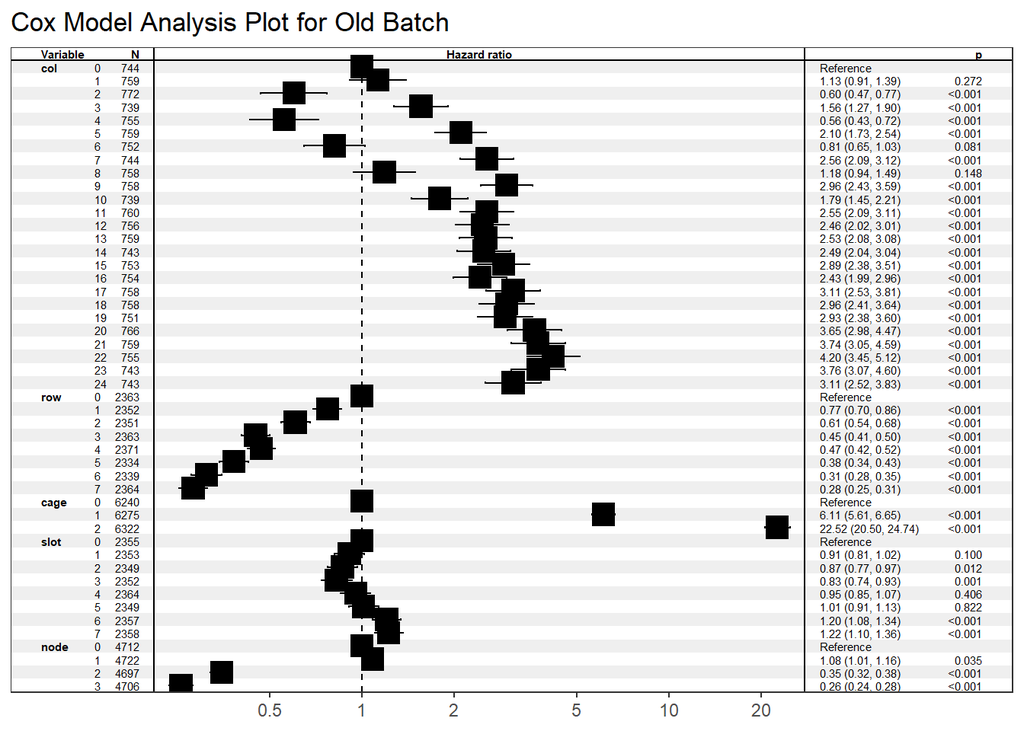

```r
forest_model_old <- forest_model(cox_old) + ggtitle("Cox Model Analysis Plot for Old Batch")
forest_model_new <- forest_model(cox_new) + ggtitle("Cox Model Analysis Plot for New Batch")

print(forest_model_old)
```

```r
print(forest_model_new)
```

```
## `height` was translated to `width`.
```

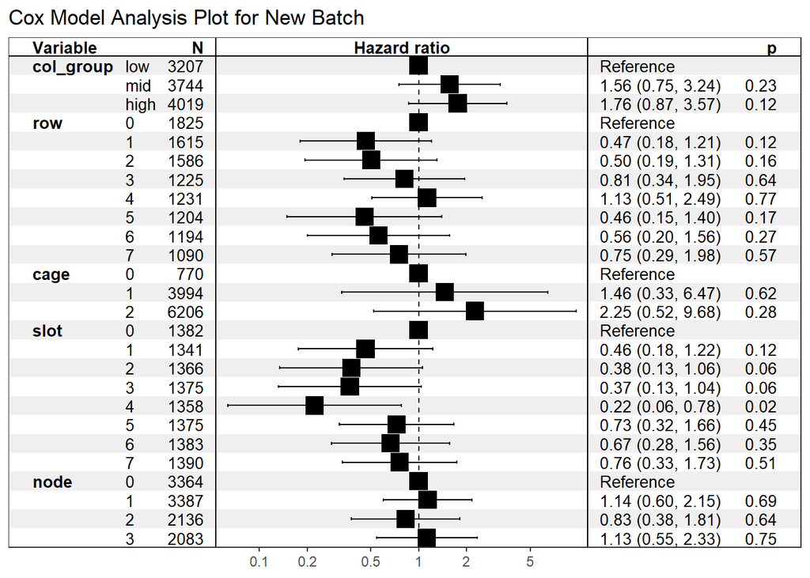

## 6. Time Between Failures (TBF) Aanalysis:

We will be using `gc_full.csv` to compute device-level Mean Time Between Failures (MTBF) for DBE and OTB events separately

```r
names(gc_full)
```

```
## [1] "SN"       "location" "insert"   "remove"   "duration" "out"      "event"
```

```r
table(gc_full$event)
```

```
##
##         DBE   OTB
## 30976  4826  1541
```

Preprocessing of `gc_full.csv` for TBF analysis:

```r
# Parsing datetime columns and event indicator
gc_full <- gc_full %>% mutate(
  insert = ymd_hms(insert, quiet = TRUE),
  remove = ymd_hms(remove, quiet = TRUE),
  event_flag = ifelse(event %in% c("DBE", "OTB"), 1, 0))

# Identifying old vs. new batch by first insert date per SN
batch_labels <- gc_full %>%
  group_by(SN) %>%
  summarise(first_insert = min(insert, na.rm = TRUE)) %>%
  mutate(batch_tbf = if_else(year(first_insert) >= 2016, "New", "Old"))

gc_full <- gc_full %>% left_join(batch_labels, by = "SN")
```

```r
# Computing device-level MTBF for each failure type
# For the first event considering time from insert to event and for subsequent event considering time since previous event on the same SN
compute_mtbf <- function(df, event_col) {
  df %>%
    filter(event == event_col) %>%
    arrange(SN, insert) %>%
    group_by(SN) %>%
    mutate(
      prev_remove = lag(remove),
      tbf_years   = if_else(
        is.na(prev_remove),
        as.numeric(difftime(insert, first(insert), units = "days")) / 365.25,
        as.numeric(difftime(insert, prev_remove,   units = "days")) / 365.25
      )
    ) %>%
    filter(tbf_years > 0) %>%
    summarise(mtbf = mean(tbf_years, na.rm = TRUE), .groups = "drop") %>%
    left_join(batch_labels %>% select(SN, batch_tbf), by = "SN") %>%
    mutate(failure_type = event_col)
}

mtbf_dbe <- compute_mtbf(gc_full, "DBE")
mtbf_otb <- compute_mtbf(gc_full, "OTB")
mtbf_all <- bind_rows(mtbf_dbe, mtbf_otb)
```

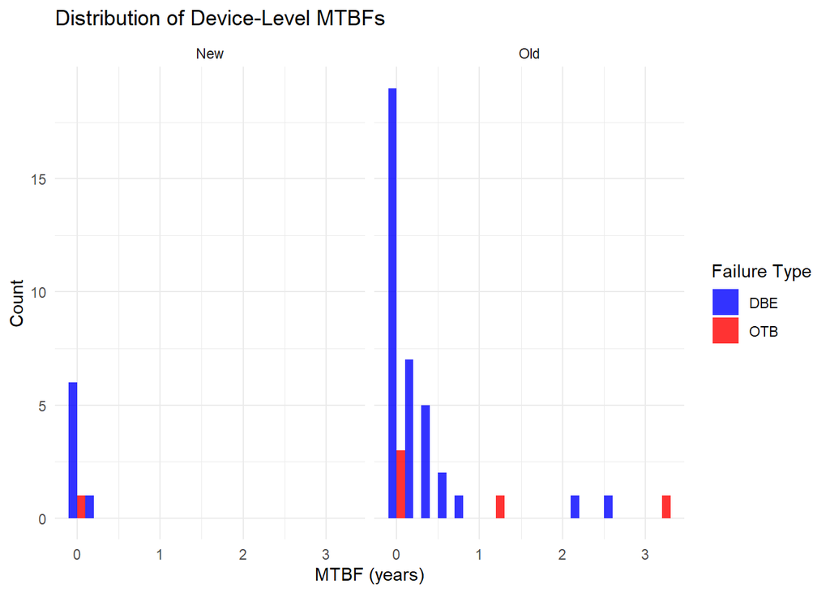

```r
#histogram of device-level MTBFs by batch and failure type
mtbf_all <- mtbf_all %>% mutate(
    batch_tbf = as.factor(batch_tbf),
    failure_type = toupper(failure_type)) %>% filter(!is.na(batch_tbf))

ggplot(mtbf_all,
       aes(x = mtbf, fill = failure_type)) +
  geom_histogram(binwidth = 0.2, position = "dodge", alpha = 0.8) +
  facet_wrap(~batch_tbf, ncol = 2) +
  scale_fill_manual(
    values = c("DBE" = "blue", "OTB" = "red")) +
  labs(
    title = "Distribution of Device-Level MTBFs",
    x     = "MTBF (years)",
    y     = "Count",
    fill  = "Failure Type"
  ) +
  theme_minimal()
```